# Classification

Razieh Pourhasan and Soufiane Fadel

# Objective

The ability to monitor and perform early forecast of various river algae blooms is crucial to control the ecological harm they can cause. The objective of this document is to use *algae_blooms.csv* dataset to train several learning models in predicting the presence or absence of type a1 and a2 of algae blooms. The dataset consists of:

- the characteristics of the collection process for each sample (3 features: season, size, speed)
- chemical properties of various water samples of European rivers (8 features: mxPH, mnO2, Cl, NO3, NH4, oPO4, PO4, Chla).
- the quantity of seven algae in each of the samples, labeled as a1,…, a7, from which we choose a1 and a2.

# Install and Load Packages

The `pacman` package is used to install and load all necessary packages.

```r
# install.packages("pacman", verbose = F, quiet = T)
pacman::p_load(VIM, mice, rpart, rpart.plot, readr, dplyr, ggplot2, GGally, corrplot, gridExtra, pROC, MASS, caTools, caret, caretEnsemble, doMC, rsample, earth, pdp, vip, nnet, gbm, party, randomForest, install = T)
```

# Importing the Data

The data was downloaded from the course dataset folder and saved into a local folder. The csv file is loaded with the function `read.csv` in R and is stored into an R data frame `data`:

```r
data <- read.csv("~/Desktop/DataAnalysis/algae_blooms.csv")
head(data)
```

```
##   season  size  speed mxPH mnO2     Cl    NO3     NH4    oPO4     PO4 Chla
## 1 winter small medium 8.00  9.8 60.800  6.238 578.000 105.000 170.000 50.0
## 2 spring small medium 8.35  8.0 57.750  1.288 370.000 428.750 558.750  1.3
## 3 autumn small medium 8.10 11.4 40.020  5.330 346.667 125.667 187.057 15.6
## 4 spring small medium 8.07  4.8 77.364  2.302  98.182  61.182 138.700  1.4
## 5 autumn small medium 8.06  9.0 55.350 10.416 233.700  58.222  97.580 10.5
## 6 winter small   high 8.25 13.1 65.750  9.248 430.000  18.250  56.667 28.4
##     a1   a2   a3  a4   a5   a6  a7
## 1  0.0  0.0  0.0 0.0 34.2  8.3 0.0
## 2  1.4  7.6  4.8 1.9  6.7  0.0 2.1
## 3  3.3 53.6  1.9 0.0  0.0  0.0 9.7
## 4  3.1 41.0 18.9 0.0  1.4  0.0 1.4
## 5  9.2  2.9  7.5 0.0  7.5  4.1 1.0
## 6 15.1 14.6  1.4 0.0 22.5 12.6 2.9
```

```r
tail(data)
```

```
##     season   size speed mxPH mnO2      Cl   NO3    NH4    oPO4    PO4
## 335 winter  large  high 8.10 10.9  9.0560 0.825  41.00  20.000 58.000
## 336 summer medium  high 8.12 10.2  7.6130 0.699  33.56  28.034 49.658
## 337 winter  large   low 8.43 10.8 35.6420 6.225 134.00 103.500     NA
## 338 winter  large   low 8.70 11.7 21.4656 3.765  91.45  38.000 83.000
## 339 summer  large   low 8.10  8.2 26.5400 2.805  42.75  48.500 88.125
## 340 autumn  large   low 8.35 11.1 22.5600 3.140  76.20  41.000 98.665
##       Chla   a1   a2  a3 a4  a5  a6  a7
## 335     NA 16.8 19.6 4.0  0 0.0 0.0 0.0
## 336  2.200 18.1  1.7 2.0  0 1.7 5.9 0.0
## 337 45.375  1.1  3.9 2.1  0 3.9 4.6 2.3
## 338 17.000  0.0  4.7 0.0  0 2.6 2.6 0.0
## 339 13.980  0.0 12.0 1.7  0 2.7 0.0 0.0
## 340 17.456  1.7  7.0 1.2  0 4.8 3.1 0.0
```

# Exploratory Data Analyisis

Check the structure of the dataset with function `str`:

```r
str(data)
```

```
## 'data.frame':    340 obs. of  18 variables:
##  $ season: Factor w/ 4 levels "autumn","spring",..: 4 2 1 2 1 4 3 1 4 4 ...
##  $ size  : Factor w/ 3 levels "large","medium",..: 3 3 3 3 3 3 3 3 3 3 ...
##  $ speed : Factor w/ 3 levels "high","low","medium": 3 3 3 3 3 1 1 1 3 1 ...
##  $ mxPH  : num  8 8.35 8.1 8.07 8.06 8.25 8.15 8.05 8.7 7.93 ...
##  $ mnO2  : num  9.8 8 11.4 4.8 9 13.1 10.3 10.6 3.4 9.9 ...
##  $ Cl    : num  60.8 57.8 40 77.4 55.4 ...
##  $ NO3   : num  6.24 1.29 5.33 2.3 10.42 ...
##  $ NH4   : num  578 370 346.7 98.2 233.7 ...
##  $ oPO4  : num  105 428.8 125.7 61.2 58.2 ...
##  $ PO4   : num  170 558.8 187.1 138.7 97.6 ...
##  $ Chla  : num  50 1.3 15.6 1.4 10.5 ...
##  $ a1    : num  0 1.4 3.3 3.1 9.2 15.1 2.4 18.2 25.4 17 ...
##  $ a2    : num  0 7.6 53.6 41 2.9 14.6 1.2 1.6 5.4 0 ...
##  $ a3    : num  0 4.8 1.9 18.9 7.5 1.4 3.2 0 2.5 0 ...
##  $ a4    : num  0 1.9 0 0 0 0 3.9 0 0 2.9 ...
##  $ a5    : num  34.2 6.7 0 1.4 7.5 22.5 5.8 5.5 0 0 ...
##  $ a6    : num  8.3 0 0 0 4.1 12.6 6.8 8.7 0 0 ...
##  $ a7    : num  0 2.1 9.7 1.4 1 2.9 0 0 0 1.7 ...
```

The dataset `algae_bloom` contains 340 observation of 18 variables:

- 3 are categorical referring to the characteristics of the collection process for each sample: season, size, speed.
- of numerical variables 8 are associated with chemical properties of various water samples of European rivers: mxPH, mnO2, Cl, NO3, NH4, oPO4, PO4, Chla.
- the remaining 7 numerical features would refer to the quantity of seven algae in each of the samples, labeled as a1,…, a7, from which we choose a1 and a2.

Print the summary statistics for all variables and check for missing (NA) values:

```r
summary(data)
```

```
##     season       size        speed          mxPH            mnO2
##  autumn:80   large : 83   high  :142   Min.   :5.600   Min.   : 1.500
##  spring:84   medium:136   low   : 58   1st Qu.:7.750   1st Qu.: 7.925
##  summer:86   small :121   medium:140   Median :8.045   Median : 9.700
##  winter:90                             Mean   :7.997   Mean   : 9.157
##                                        3rd Qu.:8.393   3rd Qu.:10.800
##                                        Max.   :9.700   Max.   :13.400
##                                        NA's   :2       NA's   :2
##        Cl               NO3              NH4                oPO4
##  Min.   :  0.222   Min.   : 0.000   Min.   :    5.00   Min.   :   1.00
##  1st Qu.: 10.994   1st Qu.: 1.147   1st Qu.:   37.86   1st Qu.:  13.00
##  Median : 32.470   Median : 2.356   Median :  107.36   Median :  37.24
##  Mean   : 42.517   Mean   : 3.121   Mean   :  471.73   Mean   :  73.09
##  3rd Qu.: 57.750   3rd Qu.: 4.147   3rd Qu.:  244.90   3rd Qu.:  88.11
##  Max.   :391.500   Max.   :45.650   Max.   :24064.00   Max.   :1435.00
##  NA's   :16        NA's   :2        NA's   :2          NA's   :2
##       PO4              Chla               a1              a2
##  Min.   :   1.0   Min.   :  0.200   Min.   : 0.00   Min.   : 0.000
##  1st Qu.:  40.0   1st Qu.:  2.133   1st Qu.: 1.50   1st Qu.: 0.000
##  Median : 101.5   Median :  5.111   Median : 7.10   Median : 2.800
##  Mean   : 136.7   Mean   : 12.796   Mean   :16.70   Mean   : 7.201
##  3rd Qu.: 200.2   3rd Qu.: 17.200   3rd Qu.:25.18   3rd Qu.:10.150
##  Max.   :1690.0   Max.   :110.456   Max.   :89.80   Max.   :72.600
##  NA's   :7        NA's   :23
##        a3               a4              a5               a6
##  Min.   : 0.000   Min.   : 0.00   Min.   : 0.000   Min.   : 0.000
##  1st Qu.: 0.000   1st Qu.: 0.00   1st Qu.: 0.000   1st Qu.: 0.000
##  Median : 1.400   Median : 0.00   Median : 2.200   Median : 0.000
##  Mean   : 3.904   Mean   : 1.81   Mean   : 5.516   Mean   : 6.411
##  3rd Qu.: 4.625   3rd Qu.: 2.30   3rd Qu.: 8.000   3rd Qu.: 7.025
##  Max.   :42.800   Max.   :44.60   Max.   :61.100   Max.   :77.600
##
##        a7
##  Min.   : 0.000
##  1st Qu.: 0.000
##  Median : 0.000
##  Mean   : 2.206
##  3rd Qu.: 2.200
##  Max.   :31.600
##
```

```r
# Check number of NA values in each column
colSums(is.na(data), na.rm = F)
```

```
## season   size  speed   mxPH   mnO2     Cl    NO3    NH4   oPO4    PO4
##      0      0      0      2      2     16      2      2      2      7
##   Chla     a1     a2     a3     a4     a5     a6     a7
##     23      0      0      0      0      0      0      0
```

There are missing values: 23 from `Chla`, 16 from `Cl`, 7 from `PO4` and so on. Before dealing with the missing values take a look at the barplot and histogram of categorical and numerical variables:

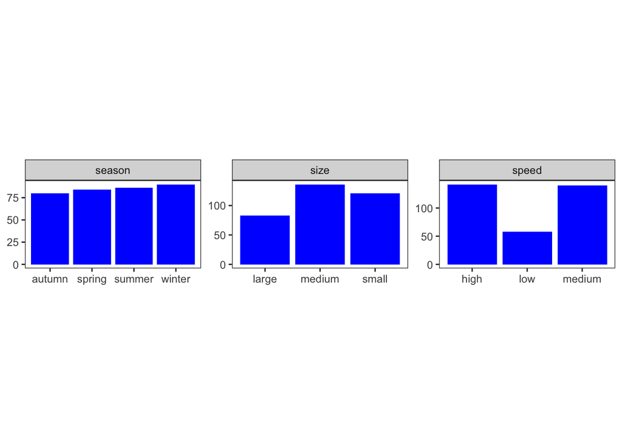

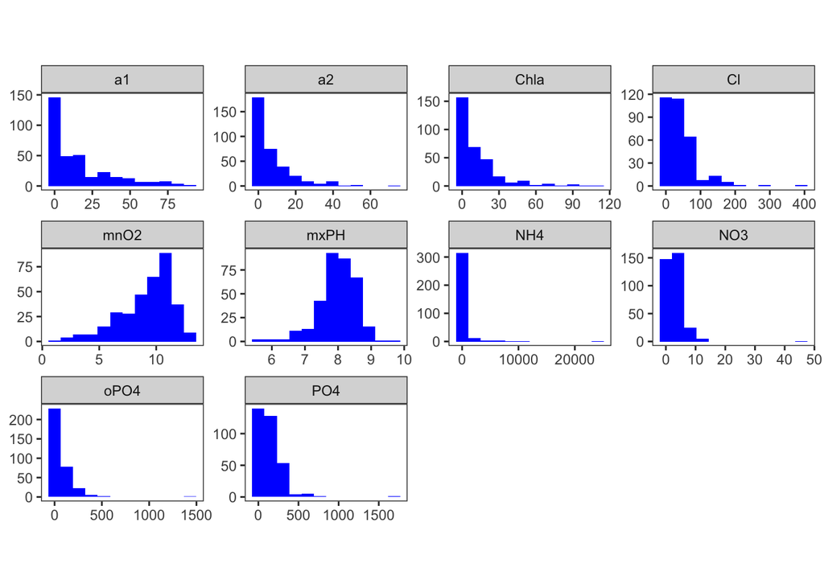

## Looking at Missing Data Pattern

Perhaps more helpful visual representation can be obtained by using the `aggr` function in `VIM` package as follows:

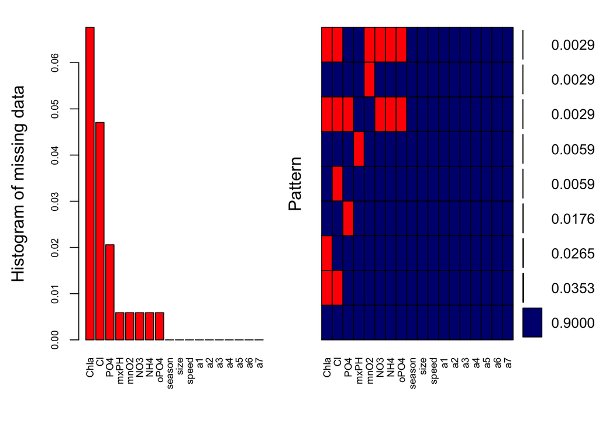

```
##
##  Variables sorted by number of missings:
##  Variable       Count
##      Chla 0.067647059
##        Cl 0.047058824
##       PO4 0.020588235
##      mxPH 0.005882353
##      mnO2 0.005882353
##       NO3 0.005882353
##       NH4 0.005882353
##      oPO4 0.005882353
##    season 0.000000000
##      size 0.000000000
##     speed 0.000000000
##        a1 0.000000000
##        a2 0.000000000
##        a3 0.000000000
##        a4 0.000000000
##        a5 0.000000000
##        a6 0.000000000
##        a7 0.000000000
```

The above plot helps understanding that almost 90% of the samples are not missing any information, about 7% are missing the `chla`, 5% are missing`cl` value, and the remaining ones show other missing patterns.

## Imputing the Missing Data

- m=5 refers to the number of imputed datasets. Five is the default value.
- meth=‘pmm’ refers to the imputation method. In this case we are using predictive mean matching as imputation method. Other imputation methods can be used.

Print the summary statistics of imputed data:

```r
summary(tempData)
```

```
## Class: mids
## Number of multiple imputations:  5
## Imputation methods:
## season   size  speed   mxPH   mnO2     Cl    NO3    NH4   oPO4    PO4
##     ""     ""     ""  "pmm"  "pmm"  "pmm"  "pmm"  "pmm"  "pmm"  "pmm"
##   Chla     a1     a2     a3     a4     a5     a6     a7
##  "pmm"     ""     ""     ""     ""     ""     ""     ""
## PredictorMatrix:
##        season size speed mxPH mnO2 Cl NO3 NH4 oPO4 PO4 Chla a1 a2 a3 a4 a5
## season      0    1     1    1    1  1   1   1    1   1    1  1  1  1  1  1
## size        1    0     1    1    1  1   1   1    1   1    1  1  1  1  1  1
## speed       1    1     0    1    1  1   1   1    1   1    1  1  1  1  1  1
## mxPH        1    1     1    0    1  1   1   1    1   1    1  1  1  1  1  1
## mnO2        1    1     1    1    0  1   1   1    1   1    1  1  1  1  1  1
## Cl          1    1     1    1    1  0   1   1    1   1    1  1  1  1  1  1
##        a6 a7
## season  1  1
## size    1  1
## speed   1  1
## mxPH    1  1
## mnO2    1  1
## Cl      1  1
```

Check the imputed data, for instance for the variable `Chla`:

```r
tempData$imp$Chla
```

```
##          1      2      3      4      5
## 55   0.600  0.675  0.500  2.460  0.800
## 56   2.500  0.800  0.500  0.500  0.800
## 57   0.500  0.800  0.700  0.700  0.500
## 58   2.500  0.800  0.800  4.500  0.500
## 59   0.700  0.700  0.500  0.500  2.500
## 60   2.500  0.500  0.700  0.800  0.700
## 61   0.500  0.700  0.700  0.500  0.800
## 62   2.500  0.500  2.500  0.800  2.500
## 63   0.500  0.800  1.200  3.300  4.300
## 116 39.333 18.330 13.980 20.600  3.000
## 184  5.544  3.950 21.900  2.859  2.100
## 199  2.200  5.620 81.540 22.900  6.429
## 201 25.000  0.800  6.167  6.809 13.000
## 219  2.100 10.000  1.000  0.600  2.200
## 231  2.500  0.500  1.100  0.800  0.800
## 235  0.700  0.800  2.500  0.500  0.500
## 236  0.500  2.700  0.600  2.100  2.460
## 237  0.500  0.800  0.700  2.500  0.800
## 238  0.700  0.500  0.800  0.500  2.500
## 239  0.500  0.600  0.700  2.100  2.460
## 241  7.430  0.800  2.000  3.500  1.900
## 330  0.500  0.800  3.300  0.675  0.500
## 335 17.200  2.800 54.200  1.400  9.384
```

which shows the imputed data for each observation within each imputed dataset.

Check the imputation method used for each variable:

```r
tempData$meth
```

```
## season   size  speed   mxPH   mnO2     Cl    NO3    NH4   oPO4    PO4
##     ""     ""     ""  "pmm"  "pmm"  "pmm"  "pmm"  "pmm"  "pmm"  "pmm"
##   Chla     a1     a2     a3     a4     a5     a6     a7
##  "pmm"     ""     ""     ""     ""     ""     ""     ""
```

A useful visual take on the distributions can be obtained using the `stripplot` function that shows the distributions of the variables as individual points. The imputed data is shown in red (remember there were 5 imputed datasets) while the observed data is showed in blue. One would like to see that the red points (imputed) are within the spread of the blue ones (observed) implying that the imputed values are indeed “plausible values”:

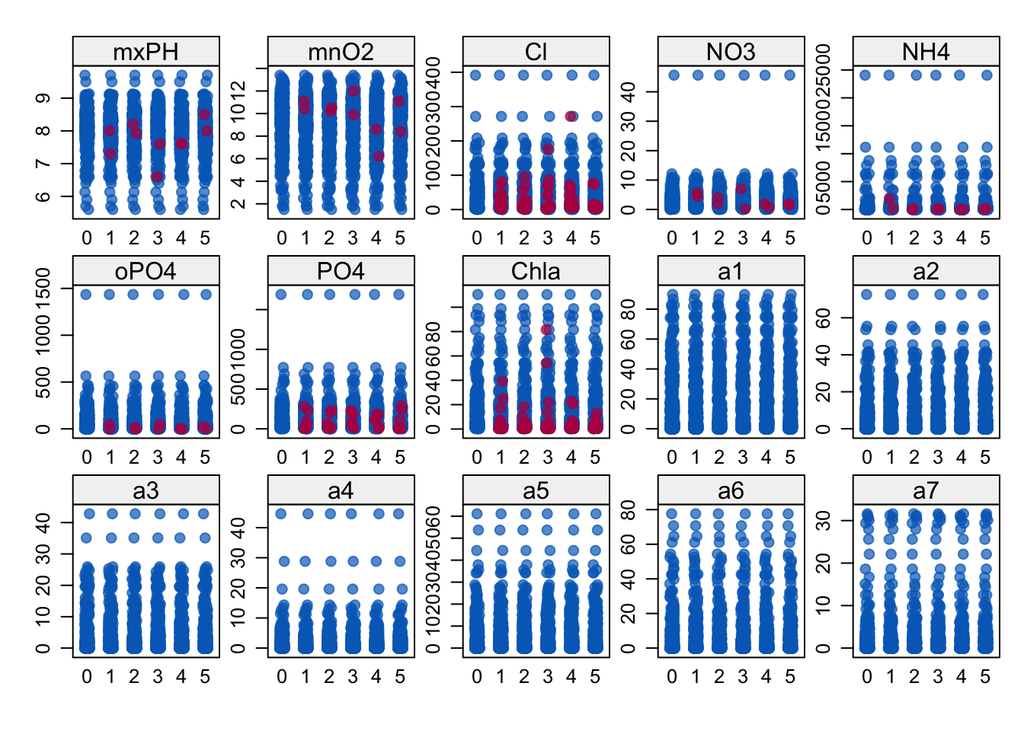

```r
stripplot(tempData, pch = 20, cex = 1.2)
```

Get back the completed dataset using function `complete`:

```r
data <- mice::complete(tempData,1)
```

The missing values have been replaced with the imputed values in the first of the five datasets. Another one could be used by changing the second parameter in the `complete` function.

## Correlation

Plot correlation map:

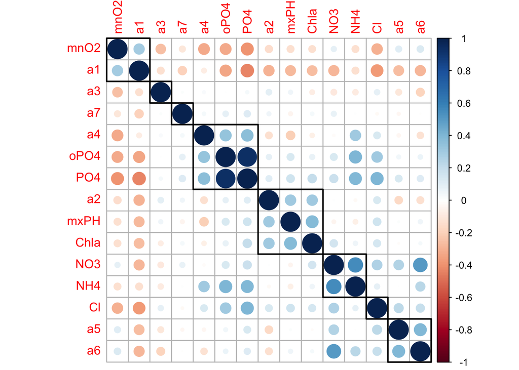

There seems to be a considerable positive correlation between `PO4` and `oPO4`, therefore one of them could be dropped. Keep `oPO4` because it has less missing values than `PO4`. Most pairwise correlations between predictors are generally low.

Since the task of this project is to predict presence or absence of algae `a1` and `a2`, drop `a3` to `a7` from the data as well:

```r
old.data = data
data = subset(data, select = -c(PO4, a3, a4, a5, a6, a7) )
```

Print summary of the updated data:

```r
summary(data)
```

```
##     season       size        speed          mxPH            mnO2
##  autumn:80   large : 83   high  :142   Min.   :5.600   Min.   : 1.500
##  spring:84   medium:136   low   : 58   1st Qu.:7.747   1st Qu.: 7.975
##  summer:86   small :121   medium:140   Median :8.035   Median : 9.750
##  winter:90                             Mean   :7.995   Mean   : 9.166
##                                        3rd Qu.:8.377   3rd Qu.:10.800
##                                        Max.   :9.700   Max.   :13.400
##        Cl               NO3              NH4                oPO4
##  Min.   :  0.222   Min.   : 0.000   Min.   :    5.00   Min.   :   1.00
##  1st Qu.: 10.965   1st Qu.: 1.164   1st Qu.:   38.03   1st Qu.:  13.00
##  Median : 32.265   Median : 2.392   Median :  109.50   Median :  37.24
##  Mean   : 41.749   Mean   : 3.132   Mean   :  475.08   Mean   :  72.81
##  3rd Qu.: 57.375   3rd Qu.: 4.218   3rd Qu.:  245.34   3rd Qu.:  87.59
##  Max.   :391.500   Max.   :45.650   Max.   :24064.00   Max.   :1435.00
##       Chla               a1              a2
##  Min.   :  0.200   Min.   : 0.00   Min.   : 0.000
##  1st Qu.:  2.000   1st Qu.: 1.50   1st Qu.: 0.000
##  Median :  4.633   Median : 7.10   Median : 2.800
##  Mean   : 12.276   Mean   :16.70   Mean   : 7.201
##  3rd Qu.: 17.000   3rd Qu.:25.18   3rd Qu.:10.150
##  Max.   :110.456   Max.   :89.80   Max.   :72.600
```

## Visualizing Feature relationships with a scatterplot matrix

Use a scatterplot matrix to understand the relationship between each predictor and the target feature, for example a1:

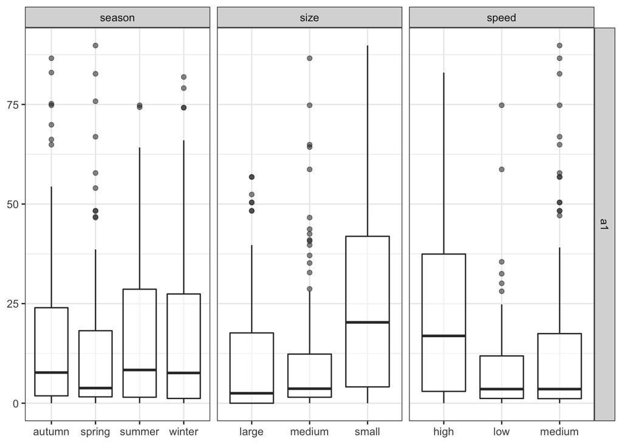

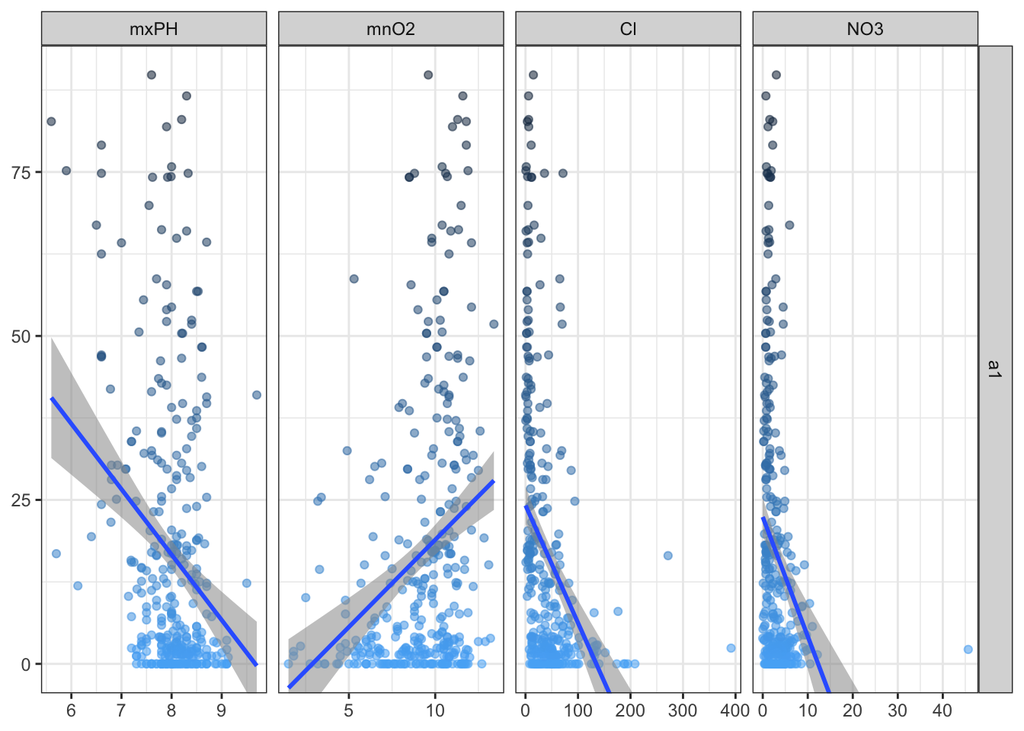

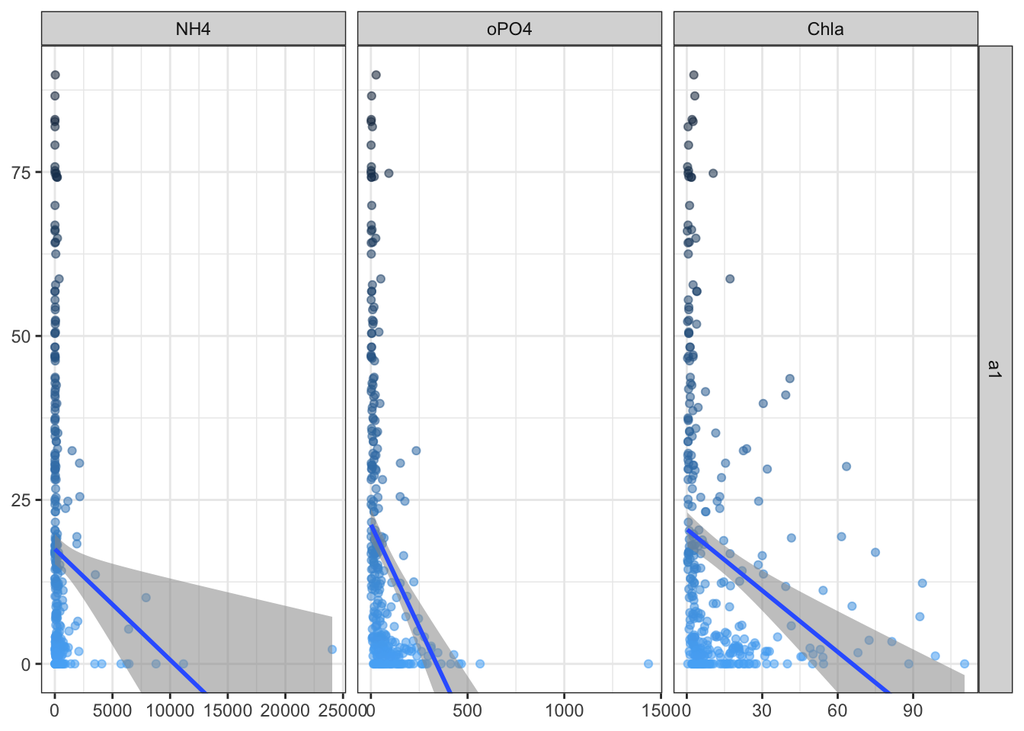

# Modelling

Since the task is predicting the presence or absence of a1 (or a2), first look at the barplot probability of a1 and a2 values:

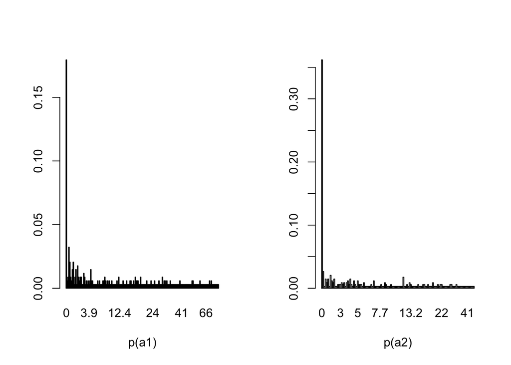

```r
p.a1=prop.table(table(data$a1))
p.a2=prop.table(table(data$a2))
par(mfrow=c(1,2))
barplot(p.a1,xlab='p(a1)')
barplot(p.a2,xlab='p(a2)')
```

```r
p.a1=prop.table(table(data$a1==0))
p.a2=prop.table(table(data$a2==0))
cbind(p.a1,p.a2)
```

```
##            p.a1      p.a2
## FALSE 0.8205882 0.6382353
## TRUE  0.1794118 0.3617647
```

The probability of 0 for a1 or a2 is 0.18 and 0.36, respectively. The probability of presence and absence is unbalanced for both a1 and a2.

# Modelling for a1

For the purpose of classification, it is useful to convert a1 to a binary value (factor): ‘yes’ for the presence and ‘no’ for the absence. What is the threshold to have a balanced probability for the presence and absence of a1? After couple of trials, it turns out that a balanced probability is gained by setting the threshold to 7. From the summary statistics it is evident that a1 could be as high as 90. Therefore, it is not irrelevant to set the threshold to 7 to get a balanced probability which can be helpful in the process of training:

```r
data1 = NULL
data1 = subset(data,select= -c(a2))
t.a1 = 7
data1$new.a1 = NA
data1$new.a1[data1$a1>t.a1] = 'yes'
data1$new.a1[data1$a1<t.a1 | data1$a1==t.a1] = 'no'
data1 = subset( data1, select = -c(a1) )
data1$new.a1 = as.factor(data1$new.a1)
prop.table(table(data1$new.a1))
```

```
##
##  no yes
## 0.5 0.5
```

Print the summary statistics for new data `data1` after converting a1 to a binary factor value `new.a1`:

```r
summary(data1)
```

```
##     season       size        speed          mxPH            mnO2
##  autumn:80   large : 83   high  :142   Min.   :5.600   Min.   : 1.500
##  spring:84   medium:136   low   : 58   1st Qu.:7.747   1st Qu.: 7.975
##  summer:86   small :121   medium:140   Median :8.035   Median : 9.750
##  winter:90                             Mean   :7.995   Mean   : 9.166
##                                        3rd Qu.:8.377   3rd Qu.:10.800
##                                        Max.   :9.700   Max.   :13.400
##        Cl               NO3              NH4                oPO4
##  Min.   :  0.222   Min.   : 0.000   Min.   :    5.00   Min.   :   1.00
##  1st Qu.: 10.965   1st Qu.: 1.164   1st Qu.:   38.03   1st Qu.:  13.00
##  Median : 32.265   Median : 2.392   Median :  109.50   Median :  37.24
##  Mean   : 41.749   Mean   : 3.132   Mean   :  475.08   Mean   :  72.81
##  3rd Qu.: 57.375   3rd Qu.: 4.218   3rd Qu.:  245.34   3rd Qu.:  87.59
##  Max.   :391.500   Max.   :45.650   Max.   :24064.00   Max.   :1435.00
##       Chla         new.a1
##  Min.   :  0.200   no :170
##  1st Qu.:  2.000   yes:170
##  Median :  4.633
##  Mean   : 12.276
##  3rd Qu.: 17.000
##  Max.   :110.456
```

## Create Validation Set

Remove 20% of the observations and save them into a validation set `val.set`. Stratified partitioning on the target feature will be applied for the creation of this set:

```r
set.seed(1234)
# Create validation set using stratified partioning (20% of observation)
data.index <- createDataPartition(data1$new.a1, p=0.8, list = FALSE)
new.data <- data1[data.index,]
val.set <- data1[-data.index,]
dim(data1)
```

```
## [1] 340  11
```

```r
dim(new.data)
```

```
## [1] 272  11
```

```r
dim(val.set)
```

```
## [1] 68 11
```

It is important to preserve the probability of presence and absence of a1 in each set after partitioning:

```r
p.new.obs = prop.table(table(new.data$new.a1))
p.val.set = prop.table(table(val.set$new.a1))
cbind(p.new.obs, p.val.set)
```

```
##     p.new.obs p.val.set
## no        0.5       0.5
## yes       0.5       0.5
```

## Create Training and Test Sets

After saving 20% of original observations into a validation set, 80% of the samples (from the 80% remaining observations) are randomly selected for the training set, and the remaining 20% (of 80%) are allocated for testing the models. Stratified partitioning on the target feature will be applied for the creation of these subsets:

```r
set.seed(1234)
data_index <- createDataPartition(new.data$new.a1, p=0.8, list = FALSE)
train_data <- new.data[data_index,]
test_data <- new.data[-data_index,]
dim(new.data)
```

```
## [1] 272  11
```

```r
dim(train_data)
```

```
## [1] 218  11
```

```r
dim(test_data)
```

```
## [1] 54 11
```

Again, it is important to check that the probability of presence and absence of a1 in each set is preserved after partitioning:

```r
p.train = prop.table(table(train_data$new.a1))
p.test = prop.table(table(test_data$new.a1))
cbind(p.train, p.test)
```

```
##     p.train p.test
## no      0.5    0.5
## yes     0.5    0.5
```

# Naive (Dummy) Classifier

Classification models are fit on a training dataset and evaluated on a test dataset, and performance is often reported as a fraction of the number of correct predictions compared to the total number of predictions made, called accuracy.

Given a classification model, how to know if the model has skill or not?

When performing classification tasks using any ML model, it is very useful to determine how well the ML model performs against a naive (dummy) classifier model. A naive classifier model is one that does not use any sophistication in order to make a prediction, typically making a random or constant prediction. Such models are naive because they don’t use any knowledge about the domain or any learning in order to make a prediction.

The performance of a naive classifier on a classification task provides a lower bound on the expected performance of all other models on the problem. It is essential that our ML model does much better that the naive classifier.

What classifier should be used as the naive classifier?

Some common choices include:

- Predict a random class.
- Predict a randomly selected class from the training dataset.
- Predict the majority class from the training dataset.

For a two-class classification problem such as the one in this project, a naive classifier could be some simple computation like frequency of majority class. For example, in an imbalanced class where there are only about 10% of positive samples, if any ML model has an accuracy of about 0.90 then it is evident that the ML classifier is not doing any better than a naive classifier which can just take a majority count of this imbalanced class and also come up with 0.90. The ML classifier needs to be able to do better than that.

R does not seem to have an explicit naive classifier but the following simple code creates a naive classifier that predicts the majority class:

```r
# Create a simple dummy (naive) classifier that computes the ratio of the majority class to the total in the training set
DummyClassifierAccuracy <- function(train,target,type="majority"){
  if(type=="majority"){
      count <- sum(ifelse(train[target]=='yes',1,0))/dim(train)[1]
  }
  count
}
```

Therefore we get a lower bound for accuracy as:

```r
acc=DummyClassifierAccuracy(train_data, target='new.a1')
paste("The baseline accuracy for predicting the presence or absence of algae bloom a1 is",acc)
```

```
## [1] "The baseline accuracy for predicting the presence or absence of algae bloom a1 is 0.5"
```

# AppLying Machine Learning Models

## Training Parameters

Parameter tuning will be done using repeated 5-fold cross-validation. Each round of cross-validation will be repeated 3 times. The `caret` package will be used for model training, tuning and evaluation.

```r
# Training Parameters
CV_folds <- 5 # number of folds
CV_repeats <- 3 # number of repeats

# Training Settings
set.seed(1)

# trainControl object for standard repeated cross-validation
fitControl <- trainControl(method="repeatedcv",
                           number = CV_folds,
                           repeats = CV_repeats,
                           savePredictions = 'final',
                           classProbs = TRUE,
                           summaryFunction = twoClassSummary)
```

## Model Fitting, Prediction and Confusion Matrix:

```r
# list of algorithms
model_list = c('rpart', 'nb', 'nnet', 'glm', 'svmLinear')
# model_list = c('ctree', 'rf', 'lda', 'knn', 'nb', 'earth') # switch to this list for part 7 of project and run

# create model_fit function
model_fit <- function(mod, fit_data){
  if (mod != 'nnet')
    train(new.a1~., fit_data, method = mod, metric = "ROC",
          preProcess = c('center', 'scale'), tuneLength = 10, trControl = fitControl)
  else train(new.a1~., fit_data, method = mod, metric = "ROC", trace = FALSE,
        preProcess = c('center', 'scale'), tuneLength = 10, trControl = fitControl)
}

# create empty lists to save trained models, preditions and confusion matrices
models20 <- list()
preds20 <- list()
cms20 <- list()

# repeat model fitting for each of 5 models 20 times; each time for a new set of train/test data and save each trial
for (i in 1:20){
  data_index <- createDataPartition(new.data$new.a1, p=0.8, list = FALSE)
  train_data <- new.data[data_index,]
  test_data <- new.data[-data_index,]
  model.fits <- lapply(model_list, model_fit, train_data) # fit each model in the list to the train data
  models20 <- append(models20, list(model.fits)) #save trained models
  names(models20)[i] <- paste0("model.fits",i)
  preds <- lapply(model.fits, predict, test_data) # make predictions for the test data
  preds20 <- append(preds20, list(preds)) # save preditions
  names(preds20)[i] <- paste0("preds",i)
  cms <- lapply(preds, confusionMatrix, test_data$new.a1, positive = "yes") # compute CMs
  cms20 <- append(cms20, list(cms)) # save CMs
  names(cms20)[i] <- paste0("cms",i)
  }

# check one of the 20 trials
models20[[2]]
```

```
## [[1]]
## CART
##
## 218 samples
##  10 predictor
##   2 classes: 'no', 'yes'
##
## Pre-processing: centered (14), scaled (14)
## Resampling: Cross-Validated (5 fold, repeated 3 times)
## Summary of sample sizes: 174, 174, 176, 174, 174, 174, ...
## Resampling results across tuning parameters:
##
##   cp          ROC        Sens       Spec
##   0.00000000  0.7942405  0.7707071  0.6880231
##   0.06625892  0.7858586  0.7826840  0.7890332
##   0.13251784  0.7858586  0.7826840  0.7890332
##   0.19877676  0.7858586  0.7826840  0.7890332
##   0.26503568  0.7858586  0.7826840  0.7890332
##   0.33129460  0.7858586  0.7826840  0.7890332
##   0.39755352  0.7858586  0.7826840  0.7890332
##   0.46381244  0.7858586  0.7826840  0.7890332
##   0.53007136  0.7858586  0.7826840  0.7890332
##   0.59633028  0.6727273  0.8349206  0.5105339
##
## ROC was used to select the optimal model using the largest value.
## The final value used for the model was cp = 0.
##
## [[2]]
## Naive Bayes
##
## 218 samples
##  10 predictor
##   2 classes: 'no', 'yes'
##
## Pre-processing: centered (14), scaled (14)
## Resampling: Cross-Validated (5 fold, repeated 3 times)
## Summary of sample sizes: 174, 175, 174, 175, 174, 175, ...
## Resampling results across tuning parameters:
##
##   usekernel  ROC        Sens       Spec
```

[output cut: 144 more lines]

```
## Support Vector Machines with Linear Kernel
##
## 218 samples
##  10 predictor
##   2 classes: 'no', 'yes'
##
## Pre-processing: centered (14), scaled (14)
## Resampling: Cross-Validated (5 fold, repeated 3 times)
## Summary of sample sizes: 174, 174, 175, 174, 175, 175, ...
## Resampling results:
##
##   ROC        Sens       Spec
##   0.8206612  0.7069264  0.7705628
##
## Tuning parameter 'C' was held constant at a value of 1
```

```r
cms20[[2]]
```

```
## [[1]]
## Confusion Matrix and Statistics
##
##           Reference
## Prediction no yes
##        no  26   4
##        yes  1  23
##
##                Accuracy : 0.9074
##                  95% CI : (0.797, 0.9692)
##     No Information Rate : 0.5
##     P-Value [Acc > NIR] : 1.946e-10
##
##                   Kappa : 0.8148
##
##  Mcnemar's Test P-Value : 0.3711
##
##             Sensitivity : 0.8519
##             Specificity : 0.9630
##          Pos Pred Value : 0.9583
##          Neg Pred Value : 0.8667
##              Prevalence : 0.5000
##          Detection Rate : 0.4259
##    Detection Prevalence : 0.4444
##       Balanced Accuracy : 0.9074
##
##        'Positive' Class : yes
##
##
## [[2]]
## Confusion Matrix and Statistics
##
##           Reference
## Prediction no yes
##        no  13   2
##        yes 14  25
##
##                Accuracy : 0.7037
##                  95% CI : (0.5639, 0.8202)
##     No Information Rate : 0.5
```

[output cut: 89 more lines]

```
##                   Kappa : 0.5556
##
##  Mcnemar's Test P-Value : 0.009375
##
##             Sensitivity : 0.9630
##             Specificity : 0.5926
##          Pos Pred Value : 0.7027
##          Neg Pred Value : 0.9412
##              Prevalence : 0.5000
##          Detection Rate : 0.4815
##    Detection Prevalence : 0.6852
##       Balanced Accuracy : 0.7778
##
##        'Positive' Class : yes
##
```

## Model Result Comparison

Comparing the overall (regular) `Accuracy` of each model for each of 20 trial:

```r
df_Accuracy20 = setNames(data.frame(matrix(ncol = 5, nrow = 0)),
                         c(' Decision Tree ',' Naive Bayes ',
                           ' Neural Network ',' Logistic ',' SVM.Linear '))
for (i in 1:20){
  df_Accuracy20[nrow(df_Accuracy20) + 1,] <- sapply(cms20[[i]], function(x) x$overall['Accuracy'])
}
df_Accuracy20
```

```
##     Decision Tree   Naive Bayes   Neural Network   Logistic   SVM.Linear
## 1        0.7592593     0.7592593        0.6851852  0.7962963    0.7407407
## 2        0.9074074     0.7037037        0.8148148  0.7962963    0.7777778
## 3        0.7777778     0.8888889        0.8333333  0.8333333    0.8148148
## 4        0.7962963     0.7222222        0.7777778  0.7222222    0.7222222
## 5        0.7962963     0.8148148        0.6851852  0.7962963    0.7777778
## 6        0.7222222     0.7407407        0.7592593  0.8148148    0.7592593
## 7        0.8888889     0.7037037        0.8333333  0.8333333    0.8148148
## 8        0.8148148     0.7592593        0.7777778  0.7592593    0.7777778
## 9        0.8333333     0.7777778        0.7407407  0.7407407    0.7407407
## 10       0.7777778     0.7962963        0.7592593  0.7777778    0.7777778
## 11       0.8888889     0.7777778        0.8148148  0.8333333    0.8148148
## 12       0.7407407     0.7407407        0.7407407  0.7222222    0.7592593
## 13       0.7222222     0.6296296        0.6851852  0.6851852    0.6111111
## 14       0.7962963     0.7777778        0.8518519  0.7962963    0.7592593
## 15       0.7222222     0.7222222        0.6481481  0.7407407    0.7407407
## 16       0.8148148     0.6296296        0.7037037  0.7222222    0.7222222
## 17       0.7777778     0.7222222        0.7407407  0.7592593    0.7222222
## 18       0.7407407     0.7592593        0.7962963  0.8148148    0.7407407
## 19       0.7407407     0.7222222        0.7592593  0.7222222    0.7407407
## 20       0.9074074     0.8333333        0.7407407  0.8703704    0.8703704
```

The average of overall (regular) `Accuracy` for each model is:

```r
Ave.OverallAcurracy = colMeans(df_Accuracy20, na.rm = TRUE)
Ave.OverallAcurracy
```

```
##   Decision Tree      Naive Bayes   Neural Network         Logistic
##        0.7962963        0.7490741        0.7574074        0.7768519
##      SVM.Linear
##        0.7592593
```

Comparing the `Sensitivity` of each model for each of 20 trial:

```r
df_Sensitivity20 = setNames(data.frame(matrix(ncol = 5, nrow = 0)),
                         c(' Decision Tree ',' Naive Bayes ',
                           ' Neural Network ',' Logistic ',' SVM.Linear '))
for (i in 1:20){
  df_Sensitivity20[nrow(df_Sensitivity20) + 1,] <- sapply(cms20[[i]], function(x) x$byClass['Sensitivity'])
}
df_Sensitivity20
```

```
##     Decision Tree   Naive Bayes   Neural Network   Logistic   SVM.Linear
## 1        0.7037037     0.7037037        0.5925926  0.8518519    0.7037037
## 2        0.8518519     0.9259259        0.9259259  0.9259259    0.9629630
## 3        0.8888889     0.9259259        0.8518519  0.9259259    0.9629630
## 4        0.7777778     0.9259259        0.8518519  0.8148148    0.7777778
## 5        0.8148148     0.7777778        0.7777778  0.8518519    0.9259259
## 6        0.7037037     0.7037037        0.6666667  0.8148148    0.7037037
## 7        0.8888889     0.8888889        0.7407407  0.8888889    0.9259259
## 8        0.7037037     0.6296296        0.6666667  0.7777778    0.8148148
## 9        0.8518519     0.7777778        0.7407407  0.7777778    0.8148148
## 10       0.7037037     0.7777778        0.6296296  0.7037037    0.7407407
## 11       0.8888889     0.9259259        0.7407407  0.8148148    0.8148148
## 12       0.6666667     0.5925926        0.5555556  0.7037037    0.7407407
## 13       0.6296296     0.5925926        0.5555556  0.6296296    0.5185185
## 14       0.7407407     0.9259259        0.8888889  0.8518519    0.8518519
## 15       0.7037037     0.6666667        0.5925926  0.7777778    0.7777778
## 16       0.7777778     0.8148148        0.7037037  0.8148148    0.8888889
## 17       0.6666667     0.6296296        0.6296296  0.6666667    0.6296296
## 18       0.7037037     0.8888889        0.7407407  0.8148148    0.8148148
## 19       0.7407407     0.8518519        0.8148148  0.7777778    0.7777778
## 20       0.8888889     0.8148148        0.8148148  0.8148148    0.8148148
```

The average `Sensitivity` for each model is:

```r
Ave.Sensitivity = colMeans(df_Sensitivity20, na.rm = TRUE)
Ave.Sensitivity
```

```
##   Decision Tree      Naive Bayes   Neural Network         Logistic
##        0.7648148        0.7870370        0.7240741        0.8000000
##      SVM.Linear
##        0.7981481
```

Similarly, other metrics in the confusion matrix can be compared for each model in each trial. Their average for each model can be computed with `Average_Parameters` function which is defined as follows:

```r
Average_Parameters <- function(parameter){
  df <- setNames(data.frame(matrix(ncol = 5, nrow = 0)),
                         c(' Decision Tree ',' Naive Bayes ',
                           ' Neural Network ',' Logistic ',' SVM.Linear '))
  if (parameter!='Accuracy')
    for (i in 1:20) df[nrow(df) + 1,] <- sapply(cms20[[i]], function(x) x$byClass[parameter])
  else
    for (i in 1:20) df[nrow(df) + 1,] <- sapply(cms20[[i]], function(x) x$overall[parameter])
  Ave_Parameter <- colMeans(df, na.rm = TRUE)
  return(Ave_Parameter)
}
```

Compare the average of each metric in Confusion Matrix across different models:

```r
parameter_list =list(Sensitivity='Sensitivity', Specificity='Specificity', Pos_Pred_Value='Pos Pred Value', Neg_Pred_Value='Neg Pred Value', Precision='Precision', Recall='Recall', F1='F1', Prevalence='Prevalence', Detection_Rate='Detection Rate', Detection_Prevalence='Detection Prevalence', Balanced_Accuracy='Balanced Accuracy', Overall_Accuracy='Accuracy')

cm_avepar_results <- sapply(parameter_list, Average_Parameters)
cm_list_results <- t(cm_avepar_results)
cm_list_results
```

```
##                       Decision Tree   Naive Bayes   Neural Network
## Sensitivity                0.7648148     0.7870370        0.7240741
## Specificity                0.8277778     0.7111111        0.7907407
## Pos_Pred_Value             0.8185951     0.7446640        0.7832681
## Neg_Pred_Value             0.7822260     0.7832917        0.7493149
## Precision                  0.8185951     0.7446640        0.7832681
## Recall                     0.7648148     0.7870370        0.7240741
## F1                         0.7886168     0.7564615        0.7462251
## Prevalence                 0.5000000     0.5000000        0.5000000
## Detection_Rate             0.3824074     0.3935185        0.3620370
## Detection_Prevalence       0.4685185     0.5379630        0.4666667
## Balanced_Accuracy          0.7962963     0.7490741        0.7574074
## Overall_Accuracy           0.7962963     0.7490741        0.7574074
##                       Logistic   SVM.Linear
## Sensitivity           0.8000000    0.7981481
## Specificity           0.7537037    0.7203704
## Pos_Pred_Value        0.7682821    0.7445280
## Neg_Pred_Value        0.7947403    0.7935133
## Precision             0.7682821    0.7445280
## Recall                0.8000000    0.7981481
## F1                    0.7811598    0.7657520
## Prevalence            0.5000000    0.5000000
## Detection_Rate        0.4000000    0.3990741
## Detection_Prevalence  0.5231481    0.5388889
## Balanced_Accuracy     0.7768519    0.7592593
## Overall_Accuracy      0.7768519    0.7592593
```

Extract the best model for each metric:

```r
cm_results_max <- apply(cm_list_results, 1, which.is.max)
output_report <- data.frame(metric=names(cm_results_max),
                            best_model=colnames(cm_list_results)[cm_results_max],
                            value=mapply(function(x,y) {cm_list_results[x,y]},
                            names(cm_results_max),
                            cm_results_max))
rownames(output_report) <- NULL
output_report
```

```
##                  metric      best_model     value
## 1           Sensitivity       Logistic  0.8000000
## 2           Specificity  Decision Tree  0.8277778
## 3        Pos_Pred_Value  Decision Tree  0.8185951
## 4        Neg_Pred_Value       Logistic  0.7947403
## 5             Precision  Decision Tree  0.8185951
## 6                Recall       Logistic  0.8000000
## 7                    F1  Decision Tree  0.7886168
## 8            Prevalence    Naive Bayes  0.5000000
## 9        Detection_Rate       Logistic  0.4000000
## 10 Detection_Prevalence     SVM.Linear  0.5388889
## 11    Balanced_Accuracy  Decision Tree  0.7962963
## 12     Overall_Accuracy  Decision Tree  0.7962963
```

**NOTES:**

- The `Prevalence` is equal to 0.5 across all models and it should be so, since all samples are balanced for *new.a1* and therefore the proportion of positives/total(=prevalence) is always 0.5.
- The `Sensitivity` and `Recall` are equal since they are essentially the same by definition: they show how many relevant samples are selected, which means how well a model can predict all the interested samples in a dataset.
- There are two measures for `Accuracy`: *Overall* and *Balanced*. Here both the overall and balanced calculations produce the same accuracy, as will always happen when the test set is balanced; have the same number of examples in each class. However, if the test set is not balanced, *Balanced* accuracy is probably better than *Overall*.
- Which metric to use in selecting the best model for predicting the test set? It is recommended to use `Accuracy` (overall or balanced) only if the classes are perfectly balanced, and otherwise use `F1`. It is also useful to see ratio of positives and negatives estimation via `Precision` and `Sensitivity` (or `Recall`).

# Ensemble Modelling 1

## Correlation between models:

Compare the models and check their correlation:

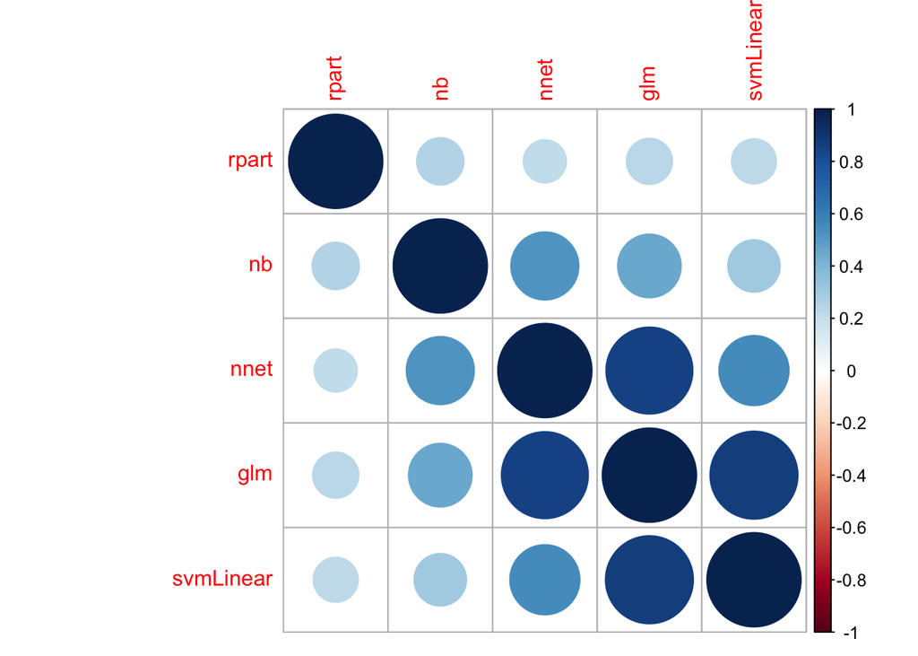

```r
resamples <- resamples(model_list)
model_cor <- modelCor(resamples)
corrplot(model_cor)
```

```r
model_cor
```

```
##               rpart        nb      nnet       glm svmLinear
## rpart     1.0000000 0.2531296 0.2102125 0.2391589 0.2289005
## nb        0.2531296 1.0000000 0.5207465 0.4550134 0.3097653
## nnet      0.2102125 0.5207465 1.0000000 0.8503194 0.5522035
## glm       0.2391589 0.4550134 0.8503194 1.0000000 0.8705129
## svmLinear 0.2289005 0.3097653 0.5522035 0.8705129 1.0000000
```

Good candidates for ensemble modelling should be models with fairly low correlation, ideally un-correlated; That is, each model should capture a different aspect of the data, and different models perform best on different subsets of the data. Out of 5 models chosen in this example glm and svmLinear together are not good for ensemble since they are highly correlated, i.e. combining them together won’t improve the prediction.

## Comparison

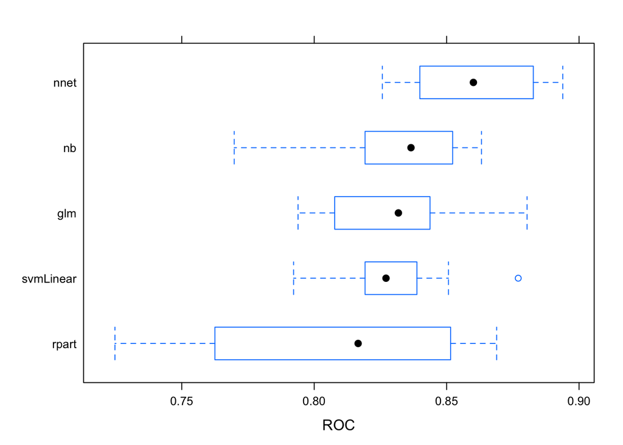

```r
bwplot(resamples, metric="ROC")
```

## Ensemble modelling using caretEnsemble

Create a simple linear combination of models with `caretEnsemble` function:

```r
greedy_ensemble <- caretEnsemble(
  model_list,
  metric="ROC",
  trControl=trainControl(
    number=2,
    summaryFunction=twoClassSummary,
    classProbs=TRUE
    ))
summary(greedy_ensemble)
```

```
## The following models were ensembled: rpart, nb, nnet, glm, svmLinear
## They were weighted:
## 2.6921 -0.7227 -0.8026 -2.074 -0.403 -1.2279
## The resulting ROC is: 0.8499
## The fit for each individual model on the ROC is:
##     method       ROC      ROCSD
##      rpart 0.8105996 0.04991540
##         nb 0.8295293 0.03003096
##       nnet 0.8613322 0.02342844
##        glm 0.8289601 0.02759438
##  svmLinear 0.8303767 0.02243266
```

```r
model_preds <- lapply(model_list, predict, newdata=val.set, type="prob")
model_preds <- lapply(model_preds, function(x) x[,"yes"])
model_preds <- data.frame(model_preds)
ens_preds <- predict(greedy_ensemble, newdata=val.set, type="prob")
model_preds$ensemble <- ens_preds
caTools::colAUC(model_preds, val.set$new.a1)
```

```
##               rpart        nb      nnet       glm svmLinear  ensemble
## no vs. yes 0.724481 0.8641869 0.7647059 0.8105536 0.7897924 0.8200692
```

Use `varImp` function to extract the importance of variables from each member of the ensemble, as well as the final ensemble model:

```r
varImp(greedy_ensemble)
```

```
##                overall      rpart        nb       nnet       glm svmLinear
## season        0.000000  0.0000000  0.000000  0.0000000  0.000000  0.000000
## speedlow      1.162477  0.9745536  0.000000  0.6900377  9.788495  0.000000
## speed         1.847612  0.0000000  4.759048  0.0000000  0.000000  4.759048
## seasonsummer  2.095327  0.0000000  0.000000  4.8057996  2.461126  0.000000
## sizemedium    2.123966  0.0000000  0.000000  4.5727645  4.032182  0.000000
## seasonspring  2.417973  0.0000000  0.000000  6.0976475  0.000000  0.000000
## size          2.768354  0.0000000  7.130676  0.0000000  0.000000  7.130676
## speedmedium   4.728537  0.0000000  0.000000 11.2783441  3.325191  0.000000
## sizesmall     4.770799  0.0000000  0.000000  9.4401969 13.334053  0.000000
## seasonwinter  6.112283  0.0000000  0.000000 14.9450514  2.413337  0.000000
## mnO2          7.877010  0.3299250  7.995958 10.5174170  7.223286  7.995958
## mxPH          8.447055  3.1478813  6.270132 12.9392366  5.799910  6.270132
## NH4           8.857319 21.2861725 12.998168  0.7464309  7.446539 12.998168
## Cl            9.247211 19.7114950 15.462957  0.0000000  6.752949 15.462957
## Chla         10.498011 16.4024420 13.759237  6.5665454  3.710267 13.759237
## NO3          11.439842 12.0286899 11.941830 10.0631142 14.939946 11.941830
## oPO4         15.606224 26.1188407 19.681993  7.3374141 18.772717 19.681993
```

Note that each column sums up to 100:

```r
colSums(varImp(greedy_ensemble))
```

```
##   overall     rpart        nb      nnet       glm svmLinear
##       100       100       100       100       100       100
```

## Ensemble modelling using caretStack

Function `caretStack` uses “meta-models” to ensemble collections of predictive models:

```r
glm_ensemble <- caretStack(
  model_list,
  method="glm",
  metric="ROC",
  trControl=trainControl(
    method="boot",
    number=10,
    savePredictions="final",
    classProbs=TRUE,
    summaryFunction=twoClassSummary
  )
)
model_preds2 <- model_preds
model_preds2$ensemble <- predict(glm_ensemble, newdata=val.set, type="prob")
CF <- coef(glm_ensemble$ens_model$finalModel)[-1]
colAUC(model_preds2, val.set$new.a1)
```

```
##               rpart        nb      nnet       glm svmLinear  ensemble
## no vs. yes 0.724481 0.8641869 0.7647059 0.8105536 0.7897924 0.8200692
```

Comparing with the caretEnsemble greedy optimization, the result is extremely similar. Again, the ensemble modelling does not make an improvement.

Let’s try another one, a non-linear ensemble:

```r
gbm_ensemble <- caretStack(
  model_list,
  method="gbm",
  verbose=FALSE,
  tuneLength=10,
  metric="ROC",
  trControl=trainControl(
    method="boot",
    number=10,
    savePredictions="final",
    classProbs=TRUE,
    summaryFunction=twoClassSummary
  )
)
model_preds3 <- model_preds
model_preds3$ensemble <- predict(gbm_ensemble, newdata=val.set, type="prob")
colAUC(model_preds3, val.set$new.a1)
```

```
##               rpart        nb      nnet       glm svmLinear  ensemble
## no vs. yes 0.724481 0.8641869 0.7647059 0.8105536 0.7897924 0.8278547
```

There is a little improvement but not significant. It is expected that ensemble model doesn’t make a significant improvement since the the models are fairly correlated.

# Ensemble Modeling 2

First we need to establish a baseline by which we will be able to judge the improvement of our ensemble model. For this task, we will use a `SVM` model:

```r
# Set-up parallel processing to take advantage of multiple machine cores
library(parallel)
library(doMC)
library(e1071)

numCores <- detectCores()
registerDoMC(cores = numCores)

# Function to compute classification error
classification_error <- function(conf_mat) {
  conf_mat = as.matrix(conf_mat)

  error = 1 - sum(diag(conf_mat)) / sum(conf_mat)

  return (error)
}

# Splitting data into train and test
data_index <- createDataPartition(new.data$new.a1, p=0.8, list = FALSE)
train_data <- new.data[data_index,]
test_data <- new.data[-data_index,]

# Model
svm_model <- svm(new.a1 ~ . , data = train_data, kernel = "linear")

# Perform predictions on the validation set (20% of the original data)
svm_pred <- as.factor(predict(svm_model, val.set))

svm_conf_mat <- table(true = val.set$new.a1, pred = svm_pred)

# Results
print(svm_model)
```

```
##
## Call:
## svm(formula = new.a1 ~ ., data = train_data, kernel = "linear")
##
##
## Parameters:
##    SVM-Type:  C-classification
##  SVM-Kernel:  linear
##        cost:  1
##
## Number of Support Vectors:  107
```

[output not shown]

Hence, we have a baseline. The classification error rate of the simple SVM is the metric we will use to judge the outcome of our ensemble model with. Hopefully, we will get an improvement using the `caretEnsemble` technique.

## caretList

We are now using the `caretList` function to conduct training on a set of algorithms all simultaneously without having to manually call each one:

```r
# Load the required libraries
library(caret)
library(nnet)
library(e1071)
library(caretEnsemble)

# Model to predict a1
control <- trainControl(method = "repeatedcv", number = 10, repeats = 3,
                        search = "grid", savePredictions = "final", index=createResample(train_data$new.a1, 10),
                        summaryFunction = twoClassSummary, classProbs = TRUE, verboseIter = TRUE)

# List of algorithms to use in ensemble
alg_list <- c("rpart", "glm", "nb",  "nnet", "svmLinear")
#alg_list <- c('ctree', 'rf', 'lda', 'knn', 'nb', 'earth') # switch to this list for part 7 of project and run

multi_mod <- caretList(new.a1 ~ . , data = train_data, trControl = control, methodList = alg_list, metric = "ROC")
# Results
res <- resamples(multi_mod)
summary(res)
```

```
##
## Call:
## summary.resamples(object = res)
##
## Models: rpart, glm, nb, nnet, svmLinear
## Number of resamples: 10
##
## ROC
##                Min.   1st Qu.    Median      Mean   3rd Qu.      Max. NA's
## rpart     0.7288773 0.7595302 0.7955078 0.8050841 0.8557735 0.8877778    0
## glm       0.7994048 0.8201338 0.8601782 0.8516751 0.8796814 0.8949275    0
## nb        0.7482517 0.7914446 0.8424187 0.8250984 0.8560915 0.8785425    0
## nnet      0.7800926 0.8333010 0.8717719 0.8556563 0.8841019 0.9024390    0
## svmLinear 0.7833333 0.8335749 0.8496197 0.8499870 0.8792429 0.8991430    0
##
## Sens
##                Min.   1st Qu.    Median      Mean   3rd Qu.      Max. NA's
## rpart     0.6829268 0.7753759 0.8492647 0.8429335 0.9125000 0.9736842    0
## glm       0.6428571 0.7219191 0.7743056 0.7744417 0.8360294 0.8947368    0
## nb        0.4523810 0.5890244 0.6185031 0.6247367 0.6578947 0.8157895    0
## nnet      0.6666667 0.8125000 0.8514706 0.8329464 0.8764853 0.9473684    0
## svmLinear 0.5882353 0.7112376 0.7530488 0.7730965 0.8741987 0.8947368    0
##
## Spec
##                Min.   1st Qu.    Median      Mean   3rd Qu.      Max. NA's
## rpart     0.4545455 0.5442194 0.6639610 0.6471069 0.7525641 0.8108108    0
## glm       0.6363636 0.7117424 0.7522297 0.7469620 0.7717262 0.8918919    0
## nb        0.6388889 0.7727273 0.8269841 0.8198241 0.8646739 0.9487179    0
## nnet      0.6111111 0.6627964 0.7099567 0.7157635 0.7564565 0.8409091    0
## svmLinear 0.6136364 0.6908508 0.7527778 0.7345992 0.7616460 0.8648649    0
```

## caretStack

```r
# Function to find threshold

# Values
thresholds <- seq(0, 1, .05)
num_thresh <- length(thresholds)

# Empty list to store results
errors <- rep(0, num_thresh)

iter <- 1

for (i in thresholds) {

  cat("Calculating error for threshold value-", i, "\n")

  threshold_value <- i

  val_a1_pred <- ifelse(stack_val_preds > threshold_value, "yes", "no")

  conf_mat <- table(true = val.set$new.a1, pred = val_a1_pred)

  errors[iter]<- classification_error(conf_mat)

  iter <- iter + 1
}
```

```
## Calculating error for threshold value- 0
## Calculating error for threshold value- 0.05
## Calculating error for threshold value- 0.1
## Calculating error for threshold value- 0.15
## Calculating error for threshold value- 0.2
## Calculating error for threshold value- 0.25
## Calculating error for threshold value- 0.3
## Calculating error for threshold value- 0.35
## Calculating error for threshold value- 0.4
## Calculating error for threshold value- 0.45
## Calculating error for threshold value- 0.5
## Calculating error for threshold value- 0.55
## Calculating error for threshold value- 0.6
## Calculating error for threshold value- 0.65
## Calculating error for threshold value- 0.7
## Calculating error for threshold value- 0.75
## Calculating error for threshold value- 0.8
## Calculating error for threshold value- 0.85
## Calculating error for threshold value- 0.9
## Calculating error for threshold value- 0.95
## Calculating error for threshold value- 1
```

```r
# Compute final threshold value
result <- data.table(cbind(thresholds, errors))

final_value <- result[which(result$error == min(result$errors))]

val_a1_pred <- ifelse(stack_val_preds >= final_value$thresholds, 1, 0)

# Report error rate
phase1_conf <- table(true = val.set$new.a1, pred = val_a1_pred)

cat("Classification Error for a1 Predictions:", classification_error(phase1_conf), "\n")
```

```
## Classification Error for a1 Predictions: 0.5882353
```

Now that we have created our “a1” predictions for the data, we can re-run our original model to see if the ensemble has been able to improve our classification rate.

```r
# Include predictions as part of model
val.set$new.a1 <- as.factor(val_a1_pred)

# Model
svm_final<- svm(new.a1 ~ ., data = train_data, kernel='linear')

# Predictions
svm_val_pred <- predict(svm_final, val.set)

# Results
svm_conf_mat <- table(true = val.set$new.a1, pred = svm_val_pred)

print(svm_final)
```

```
##
## Call:
## svm(formula = new.a1 ~ ., data = train_data, kernel = "linear")
##
##
## Parameters:
##    SVM-Type:  C-classification
##  SVM-Kernel:  linear
##        cost:  1
##
## Number of Support Vectors:  107
```

```r
cat("\n", "SVM Classification Error, Validation:", classification_error(svm_conf_mat), "\n")
```

```
##
##  SVM Classification Error, Validation: 0.6617647
```

# Closing Remarks

- In this document we trained several ML models for classification of algae bloom a1 (binary or two classes). We used `train` function to train each model separately on training set while we set metric equal to `ROC`. There are several other evaluation metrics in `caret` package that can be used in `train` function including:
  - **Accuracy** and **Kappa** are the default metrics which are used to evaluate algorithms on binary and multi-class classification datasets in `caret`. **Accuracy** is the percentage of correctly classifies instances out of all instances. It works best on a binary classification than multi-class classification problems because it can be less clear exactly how the accuracy breaks down across those classes. While **Kappa** is like classification accuracy, except that it is normalized at the baseline of random chance on the dataset. It is a more useful measure to use on problems that have an imbalance in the classes.
  - **RMSE and R^2** are the default metrics used to evaluate algorithms on regression datasets in `caret`. **RMSE** is the average deviation of the predictions from the observations. It is useful to get a gross idea of how well (or not) an algorithm is doing, in the units of the output variable. While **R^2** provides a “goodness of fit” measure for the predictions to the observations. This is a value between 0 and 1 for no-fit and perfect fit respectively.
  - **ROC** metrics are only suitable for binary classification problems (e.g. two classes). It is actually the area under the ROC curve or AUC. The AUC represents a models ability to discriminate between positive and negative classes. An area of 1.0 represents a model that made all predicts perfectly. An area of 0.5 represents a model as good as random. ROC can be broken down into sensitivity and specificity. A binary classification problem is really a trade-off between sensitivity and specificity. That’s why we used in our classification problem in this example.
  - **LogLoss** or Logarithmic Loss is used to evaluate binary classification but it is more common for multi-class classification algorithms. Specifically, it evaluates the probabilities estimated by the algorithms.
- To build our classification model we split a1 to two classes (presence or absence), an alternative could be splitting a1 into more than two classes (3 or more). If we do so, according to the previous remark we need to use a proper metric rather than ‘ROC’, for example ‘LogLoss’ could be a suitable metric in that case. Moreover, we split a1 such that the probability of two classes were balanced, again in this case ‘ROC’ is a proper metric. However, if we use a different threshold so that the two classes are not balanced ‘ROC’ is not the best metric to use rather we could use ‘Kappa’.
- For ensemble modelling we used `caretEnsemble` and/or `careStack`, there are other packages that could be used for this purpose, for example `SuperLearner` package. We can even customize our own layered learner and combine the ML algorithm in many different ways. In fact, here we tried two approaches in sections *Ensemble Modelling 1* and *Ensemble Modelling 2* but we are not satisfied by any of them. Thus, it is still an ongoing work to build a strong ensemble.
- For the part 7 of the project, we choose algorithms (‘ctree’, ‘rf’, ‘lda’, ‘knn’, ‘nb’, ‘earth’) and we switch to this list of algorithms that is provided in the corresponding code chunk beside the original list of algorithms and run the whole file.